# Project: Investigate a Dataset - [Database_No_show_appointments]

## Dataset Description

This dataset collects information from 100k medical appointments in Brazil and is focused on the question of whether or not patients show up for their appointment. A number of characteristics about the patient are included in each row.

### columns Description in dataset :

- PatientId - Identification of Patient.
- AppointmentID - Identification of Appointment.
- Gender -Male or Female (M,F).
- ScheduledDay - The day that patient registered an appointment.
- AppointmentDay - The day of appointment.
- Age - Age of patient.
- Neighbourhood - The place where the appointment takes place.
- Scholarship - In Brazil,Scholarship as a subsidy for very low-income families if they have they children going to school and other more specific requirements(0 who have't Scholarship ,1 who have Scholarship).
- Hipertension - People who have hypertension (0 not have ,1 have ).
- Diabetes - People who have Diabetes or not (0 not have ,1 have ).
- Alcoholism - People who have Alcoholism or not (0 not have ,1 have ).
- Handcap - People who have Handcap (0,1,2,3,4).
- SMS_received - messages sent to the patient or not (0,1)
- No-show - patient show up or not ('Yes' no show ,'No' show up)

### Question(s) for Analysis

```python
# Use this cell to set up import statements for all of the packages that you
#   plan to use.

# Remember to include a 'magic word' so that your visualizations are plotted
#   inline with the notebook. See this page for more:
#   http://ipython.readthedocs.io/en/stable/interactive/magics.html

# import libraries
import pandas as pd
import numpy as np
import matplotlib.pyplot as plt
import seaborn as sns
%matplotlib inline
```

```python
# Upgrade pandas to use dataframe.explode() function.
!pip install --upgrade pandas==0.25.0
```

## Data Wrangling

In this section of the report, we will load in the data, check for cleanliness, and then trim and clean your dataset for analysis.

### General Properties

```python
# Load your data and print out a few lines. Perform operations to inspect data
#   types and look for instances of missing or possibly errant data.

df=pd.read_csv('Database_No_show_appointments/noshowappointments-kagglev2-may-2016.csv')
df.head()
```

|  | PatientId | AppointmentID | Gender | ScheduledDay | AppointmentDay | Age | Neighbourhood | Scholarship | Hipertension | Diabetes | Alcoholism | Handcap | SMS_received | No-show |
| --- | --- | --- | --- | --- | --- | --- | --- | --- | --- | --- | --- | --- | --- | --- |
| 0 | 2.987250e+13 | 5642903 | F | 2016-04-29T18:38:08Z | 2016-04-29T00:00:00Z | 62 | JARDIM DA PENHA | 0 | 1 | 0 | 0 | 0 | 0 | No |
| 1 | 5.589978e+14 | 5642503 | M | 2016-04-29T16:08:27Z | 2016-04-29T00:00:00Z | 56 | JARDIM DA PENHA | 0 | 0 | 0 | 0 | 0 | 0 | No |
| 2 | 4.262962e+12 | 5642549 | F | 2016-04-29T16:19:04Z | 2016-04-29T00:00:00Z | 62 | MATA DA PRAIA | 0 | 0 | 0 | 0 | 0 | 0 | No |
| 3 | 8.679512e+11 | 5642828 | F | 2016-04-29T17:29:31Z | 2016-04-29T00:00:00Z | 8 | PONTAL DE CAMBURI | 0 | 0 | 0 | 0 | 0 | 0 | No |
| 4 | 8.841186e+12 | 5642494 | F | 2016-04-29T16:07:23Z | 2016-04-29T00:00:00Z | 56 | JARDIM DA PENHA | 0 | 1 | 1 | 0 | 0 | 0 | No |

```python
df.info()
```

```
<class 'pandas.core.frame.DataFrame'>
RangeIndex: 110527 entries, 0 to 110526
Data columns (total 14 columns):
PatientId         110527 non-null float64
AppointmentID     110527 non-null int64
Gender            110527 non-null object
ScheduledDay      110527 non-null object
AppointmentDay    110527 non-null object
Age               110527 non-null int64
Neighbourhood     110527 non-null object
Scholarship       110527 non-null int64
Hipertension      110527 non-null int64
Diabetes          110527 non-null int64
Alcoholism        110527 non-null int64
Handcap           110527 non-null int64
SMS_received      110527 non-null int64
No-show           110527 non-null object
dtypes: float64(1), int64(8), object(5)
memory usage: 11.8+ MB
```

### Data Cleaning

```python
# After discussing the structure of the data and any problems that need to be
#   cleaned, perform those cleaning steps in the second part of this section.
df.isna().sum()
```

```
PatientId         0
AppointmentID     0
Gender            0
ScheduledDay      0
AppointmentDay    0
Age               0
Neighbourhood     0
Scholarship       0
Hipertension      0
Diabetes          0
Alcoholism        0
Handcap           0
SMS_received      0
No-show           0
dtype: int64
```

```python
df.isna().sum().any()
```

```
False
```

```python
df.duplicated().sum().any()
```

```
False
```

#### Observation1 : After examining the data set columns and rows, no missing values

#### Observation2 : After examining the data set , no duplicated rows

```python
#check data types of columns
df.dtypes
```

```
PatientId         float64
AppointmentID       int64
Gender             object
ScheduledDay       object
AppointmentDay     object
Age                 int64
Neighbourhood      object
Scholarship         int64
Hipertension        int64
Diabetes            int64
Alcoholism          int64
Handcap             int64
SMS_received        int64
No-show            object
dtype: object
```

### convert 'ScheduledDay' to datetime

```python
df['ScheduledDay']=pd.to_datetime(df['ScheduledDay'])
```

```python
df['ScheduledDay']
```

```
0        2016-04-29 18:38:08+00:00
1        2016-04-29 16:08:27+00:00
2        2016-04-29 16:19:04+00:00
3        2016-04-29 17:29:31+00:00
4        2016-04-29 16:07:23+00:00
                    ...
110522   2016-05-03 09:15:35+00:00
110523   2016-05-03 07:27:33+00:00
110524   2016-04-27 16:03:52+00:00
110525   2016-04-27 15:09:23+00:00
110526   2016-04-27 13:30:56+00:00
Name: ScheduledDay, Length: 110527, dtype: datetime64[ns, UTC]
```

### convert 'AppointmentDay' to datetime

```python
df['AppointmentDay']=pd.to_datetime(df['AppointmentDay'])
```

```python
df['AppointmentDay']
```

```
0        2016-04-29 00:00:00+00:00
1        2016-04-29 00:00:00+00:00
2        2016-04-29 00:00:00+00:00
3        2016-04-29 00:00:00+00:00
4        2016-04-29 00:00:00+00:00
                    ...
110522   2016-06-07 00:00:00+00:00
110523   2016-06-07 00:00:00+00:00
110524   2016-06-07 00:00:00+00:00
110525   2016-06-07 00:00:00+00:00
110526   2016-06-07 00:00:00+00:00
Name: AppointmentDay, Length: 110527, dtype: datetime64[ns, UTC]
```

#### convert 'PatientId ' column from float into string

```python
df['PatientId']=df['PatientId'].astype(str)
```

```python
df.dtypes
```

```
PatientId                      object
AppointmentID                   int64
Gender                         object
ScheduledDay      datetime64[ns, UTC]
AppointmentDay    datetime64[ns, UTC]
Age                             int64
Neighbourhood                  object
Scholarship                     int64
Hipertension                    int64
Diabetes                        int64
Alcoholism                      int64
Handcap                         int64
SMS_received                    int64
No-show                        object
dtype: object
```

```python
df.head()
```

|  | PatientId | AppointmentID | Gender | ScheduledDay | AppointmentDay | Age | Neighbourhood | Scholarship | Hipertension | Diabetes | Alcoholism | Handcap | SMS_received | No-show |
| --- | --- | --- | --- | --- | --- | --- | --- | --- | --- | --- | --- | --- | --- | --- |
| 0 | 29872499824296.0 | 5642903 | F | 2016-04-29 18:38:08+00:00 | 2016-04-29 00:00:00+00:00 | 62 | JARDIM DA PENHA | 0 | 1 | 0 | 0 | 0 | 0 | No |
| 1 | 558997776694438.0 | 5642503 | M | 2016-04-29 16:08:27+00:00 | 2016-04-29 00:00:00+00:00 | 56 | JARDIM DA PENHA | 0 | 0 | 0 | 0 | 0 | 0 | No |
| 2 | 4262962299951.0 | 5642549 | F | 2016-04-29 16:19:04+00:00 | 2016-04-29 00:00:00+00:00 | 62 | MATA DA PRAIA | 0 | 0 | 0 | 0 | 0 | 0 | No |
| 3 | 867951213174.0 | 5642828 | F | 2016-04-29 17:29:31+00:00 | 2016-04-29 00:00:00+00:00 | 8 | PONTAL DE CAMBURI | 0 | 0 | 0 | 0 | 0 | 0 | No |
| 4 | 8841186448183.0 | 5642494 | F | 2016-04-29 16:07:23+00:00 | 2016-04-29 00:00:00+00:00 | 56 | JARDIM DA PENHA | 0 | 1 | 1 | 0 | 0 | 0 | No |

```python
print(df.shape)
df.describe()
```

```
(110527, 14)
```

|  | AppointmentID | Age | Scholarship | Hipertension | Diabetes | Alcoholism | Handcap | SMS_received |
| --- | --- | --- | --- | --- | --- | --- | --- | --- |
| count | 1.105270e+05 | 110527.000000 | 110527.000000 | 110527.000000 | 110527.000000 | 110527.000000 | 110527.000000 | 110527.000000 |
| mean | 5.675305e+06 | 37.088874 | 0.098266 | 0.197246 | 0.071865 | 0.030400 | 0.022248 | 0.321026 |
| std | 7.129575e+04 | 23.110205 | 0.297675 | 0.397921 | 0.258265 | 0.171686 | 0.161543 | 0.466873 |
| min | 5.030230e+06 | -1.000000 | 0.000000 | 0.000000 | 0.000000 | 0.000000 | 0.000000 | 0.000000 |
| 25% | 5.640286e+06 | 18.000000 | 0.000000 | 0.000000 | 0.000000 | 0.000000 | 0.000000 | 0.000000 |
| 50% | 5.680573e+06 | 37.000000 | 0.000000 | 0.000000 | 0.000000 | 0.000000 | 0.000000 | 0.000000 |
| 75% | 5.725524e+06 | 55.000000 | 0.000000 | 0.000000 | 0.000000 | 0.000000 | 0.000000 | 1.000000 |
| max | 5.790484e+06 | 115.000000 | 1.000000 | 1.000000 | 1.000000 | 1.000000 | 4.000000 | 1.000000 |

#### drop 'AppointmentID ' column

```python
df.drop(['AppointmentID'],axis=1,inplace=True)
```

```python
df.head()
```

|  | PatientId | Gender | ScheduledDay | AppointmentDay | Age | Neighbourhood | Scholarship | Hipertension | Diabetes | Alcoholism | Handcap | SMS_received | No-show |
| --- | --- | --- | --- | --- | --- | --- | --- | --- | --- | --- | --- | --- | --- |
| 0 | 29872499824296.0 | F | 2016-04-29 18:38:08+00:00 | 2016-04-29 00:00:00+00:00 | 62 | JARDIM DA PENHA | 0 | 1 | 0 | 0 | 0 | 0 | No |
| 1 | 558997776694438.0 | M | 2016-04-29 16:08:27+00:00 | 2016-04-29 00:00:00+00:00 | 56 | JARDIM DA PENHA | 0 | 0 | 0 | 0 | 0 | 0 | No |
| 2 | 4262962299951.0 | F | 2016-04-29 16:19:04+00:00 | 2016-04-29 00:00:00+00:00 | 62 | MATA DA PRAIA | 0 | 0 | 0 | 0 | 0 | 0 | No |
| 3 | 867951213174.0 | F | 2016-04-29 17:29:31+00:00 | 2016-04-29 00:00:00+00:00 | 8 | PONTAL DE CAMBURI | 0 | 0 | 0 | 0 | 0 | 0 | No |
| 4 | 8841186448183.0 | F | 2016-04-29 16:07:23+00:00 | 2016-04-29 00:00:00+00:00 | 56 | JARDIM DA PENHA | 0 | 1 | 1 | 0 | 0 | 0 | No |

```python
print(df.shape)
df.describe()
```

```
(110527, 13)
```

|  | Age | Scholarship | Hipertension | Diabetes | Alcoholism | Handcap | SMS_received |
| --- | --- | --- | --- | --- | --- | --- | --- |
| count | 110527.000000 | 110527.000000 | 110527.000000 | 110527.000000 | 110527.000000 | 110527.000000 | 110527.000000 |
| mean | 37.088874 | 0.098266 | 0.197246 | 0.071865 | 0.030400 | 0.022248 | 0.321026 |
| std | 23.110205 | 0.297675 | 0.397921 | 0.258265 | 0.171686 | 0.161543 | 0.466873 |
| min | -1.000000 | 0.000000 | 0.000000 | 0.000000 | 0.000000 | 0.000000 | 0.000000 |
| 25% | 18.000000 | 0.000000 | 0.000000 | 0.000000 | 0.000000 | 0.000000 | 0.000000 |
| 50% | 37.000000 | 0.000000 | 0.000000 | 0.000000 | 0.000000 | 0.000000 | 0.000000 |
| 75% | 55.000000 | 0.000000 | 0.000000 | 0.000000 | 0.000000 | 0.000000 | 1.000000 |
| max | 115.000000 | 1.000000 | 1.000000 | 1.000000 | 1.000000 | 4.000000 | 1.000000 |

## Exploratory Data Analysis

Now that we've trimmed and cleaned your data, we're ready to move on to exploration. **Compute statistics** and **create visualizations** with the goal of addressing the research questions that we posed in the Introduction section.

```
array([[<matplotlib.axes._subplots.AxesSubplot object at 0x7f90bdd9b358>,
      dtype=object)
```

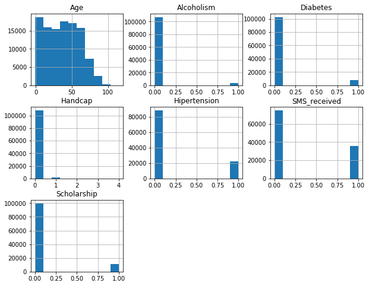

```python
# create a hist graph for each column

df.hist(figsize=(10,8))
```

#### what number of show up and no show?

```python
# check unique values of No-show
df['No-show'].unique()
```

```
array(['No', 'Yes'], dtype=object)
```

```python
# check number of poeple show up or not
df['No-show'].value_counts()
```

```
No     88208
Yes    22319
Name: No-show, dtype: int64
```

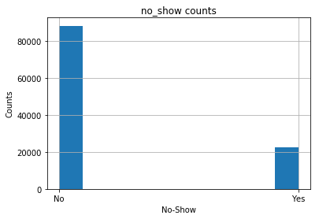

```python
# plot 'No-show' column
df['No-show'].hist()
plt.title(' no_show counts ')
plt.ylabel('counts'.title())
plt.xlabel('no-show'.title());
```

#### observation : number of people show up their appointment greater than whodo not show up their appointment

## Does Age affect Showing up for Appointments?

```python
df.groupby('No-show')['Age'].mean()
```

```
No-show
No     37.790064
Yes    34.317667
Name: Age, dtype: float64
```

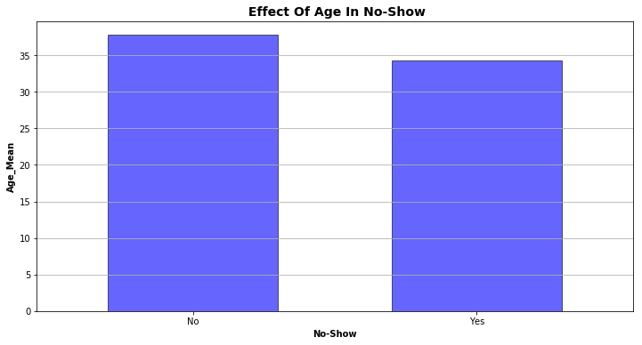

```python
def Age_noshow_Plot(df, grpVar, yVar=None, color='blue',title=None, ylabel=None, rotation=None, figsize=(14,6), alpha=0.7):
    '''base function for groupby plotting of dependent variables to no_show column'''
    # plotting
    df.groupby([grpVar])[yVar].mean().plot.bar(edgecolor='black', figsize=figsize, rot=0, width=0.6, color=color, alpha=alpha)
    plt.title(f' {title}'.title(), fontsize = 14, weight = "bold")
    plt.xlabel(grpVar.title(), fontsize =10, weight = "bold")
    plt.ylabel(f'{ylabel}'.title(), fontsize = 10, weight='bold')
    plt.xticks(rotation=rotation)
    plt.grid(axis='y')

Age_noshow_Plot(df,'No-show',yVar='Age',color='blue',title='effect of Age in no-show', ylabel='Age_mean', rotation=None, figsize=(12,6), alpha=0.6)
```

#### observation : The average age of those who show up their appointment is greater than the average age of those who don't show up.

# Does Gender affect Showing up for Appointments?

```python
df['Gender'].value_counts()
```

```
F    71840
M    38687
Name: Gender, dtype: int64
```

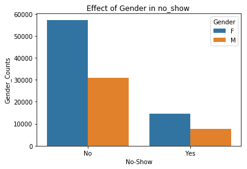

```python
sns.countplot(data=df,x='No-show',hue='Gender')
plt.title('Effect of Gender in no_show ')
plt.ylabel('Gender_counts'.title())
plt.xlabel('no-show'.title());
```

### observation :.

##### First: the number of females is greater than the number of males

##### Second: The number of females who show up their appointment is greater than the number of those who do not show up

##### Third : The number of males who show up their appointment is greater than the number of those who do not show up

# Does Hipertension affect Showing up for Appointments?

```python
# check unique value
df['Hipertension'].unique()
```

```
array([1, 0])
```

```python
# check number of poeple have Hypertension
df['Hipertension'].value_counts()
```

```
0    88726
1    21801
Name: Hipertension, dtype: int64
```

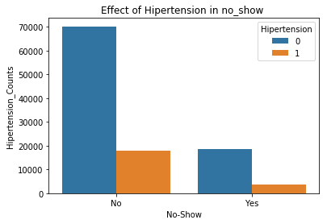

```python
sns.countplot(data=df,x='No-show',hue='Hipertension')
plt.title('Effect of Hipertension in no_show ')
plt.ylabel('Hipertension_counts'.title())
plt.xlabel('no-show'.title());
```

### observation:

#### First : the number of people who do not have Hypertension greater than who have

#### Second: The number of people who do not have Hypertension and show up is greater than those who have and show up

#### Third: The number of people who do not have Hypertension and do not show up is greater than those who have and do not show up

# Does Diabetes affect Showing up for Appointments?

```python
# check unique values of Diabetes
df['Diabetes'].unique()
```

```
array([0, 1])
```

```python
# check number of people have Diabetes
df['Diabetes'].value_counts()
```

```
0    102584
1      7943
Name: Diabetes, dtype: int64
```

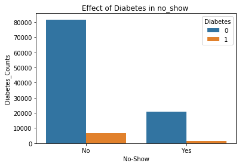

```python
# plot No-show and Diabetes
sns.countplot(data=df,x='No-show',hue='Diabetes')
plt.title('Effect of Diabetes in no_show ')
plt.ylabel('Diabetes_counts'.title())
plt.xlabel('no-show'.title());
```

### observation:

#### First : the number of people who do not have Diabetes greater than who have

#### Second: The number of people who do not have Diabetes and show up is greater than those who have and show up

#### Third: The number of people who do not have Diabetes and do not show up is greater than those who have and do not show up

## Does Alcoholism affect Showing up for Appointments?

```python
# check unique values of Alcoholism
df['Alcoholism'].unique()
```

```
array([0, 1])
```

```python
# check number of people have Alcoholism or not
df['Alcoholism'].value_counts()
```

```
0    107167
1      3360
Name: Alcoholism, dtype: int64
```

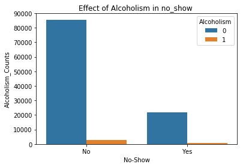

```python
# plot No-show and Alcoholism
sns.countplot(data=df,x='No-show',hue='Alcoholism')
plt.title('Effect of Alcoholism in no_show ')
plt.ylabel('Alcoholism_counts'.title())
plt.xlabel('no-show'.title());
```

### observation:

#### First : the number of people who do not have Alcoholism greater than who have

#### Second: The number of people who do not have Alcoholism and show up is greater than those who have and show up

#### Third: The number of people who do not have Alcoholism and do not show up is greater than those who have and do not show up

## Does Handcap affect Showing up for Appointments?

```python
# check unique values of Handcap
df['Handcap'].unique()
```

```
array([0, 1, 2, 3, 4])
```

```python
# check number of people have Handcap for each number of Handcap
df['Handcap'].value_counts()
```

```
0    108286
1      2042
2       183
3        13
4         3
Name: Handcap, dtype: int64
```

```python
# df.groupby('No-show')['Handcap'].value_counts().plot(kind='bar',color=['r','b','g','y','m'])
# plt.title('Effect of Handcap in no_show ')
# plt.ylabel('Handcap_counts'.title())
# plt.xlabel('no-show'.title());
```

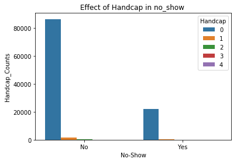

```python
sns.countplot(data=df,x='No-show',hue='Handcap')
plt.title('Effect of Handcap in no_show ')
plt.ylabel('Handcap_counts'.title())
plt.xlabel('no-show'.title());
```

### observation:

#### First : the number of people who do not have Handicap greater than who have one or more Handicap

#### Second: The number of people who do not have Handicap and show up is greater than those who have one or more Handicap and show up

#### Third: The number of people who do not have Handicap and do not show up is greater than those who have one or more Handicap and do not show up

## Does SMS_received affect Showing up for Appointments?

```python
# check unique values of SMS_received
df['SMS_received'].unique()
```

```
array([0, 1])
```

```python
# check number of people have Handcap for each number of SMS_received
df['SMS_received'].value_counts()
```

```
0    75045
1    35482
Name: SMS_received, dtype: int64
```

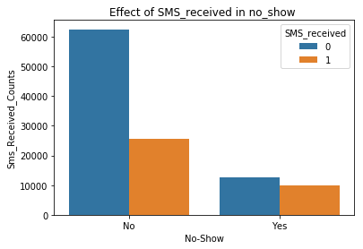

```python
# plot No-show and SMS_received
sns.countplot(data=df,x='No-show',hue='SMS_received')
plt.title('Effect of SMS_received in no_show ')
plt.ylabel('SMS_received_counts'.title())
plt.xlabel('no-show'.title());
```

### observation:

#### First : the number of people who did not receive SMS greater than who have received SMS

#### Second: The number of people who did not receive SMS , show up is greater than those who received SMS , show up

#### Third: The number of people who did not receive SMS and do not show up is greater than those who received SMS and do not show up

## Does Scholarship affect Showing up for Appointments?

```python
# check unique values
df['Scholarship'].unique()
```

```
array([0, 1])
```

```python
# check number of people who have Scholarship or not
df['Scholarship'].value_counts()
```

```
0    99666
1    10861
Name: Scholarship, dtype: int64
```

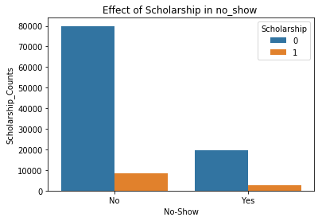

```python
# plot No-show and Scholarship
sns.countplot(data=df,x='No-show',hue='Scholarship')
plt.title('Effect of Scholarship in no_show ')
plt.ylabel('Scholarship_counts'.title())
plt.xlabel('no-show'.title());
```

### observation:

#### First : the number of people who don't have Scholarship greater than who have Scholarship

#### Second: The number of people who don't have Scholarship and show up is greater than those who have Scholarship and show up

#### Third: The number of people who don't have Scholarship and do not show up is greater than those who have Scholarship and do not show up

## Does Neighbourhood affect Showing up for Appointments?

```python
# check unique values of Neighbourhood
df['Neighbourhood'].unique()
```

```
array(['JARDIM DA PENHA', 'MATA DA PRAIA', 'PONTAL DE CAMBURI',
       'REPÚBLICA', 'GOIABEIRAS', 'ANDORINHAS', 'CONQUISTA',
       'NOVA PALESTINA', 'DA PENHA', 'TABUAZEIRO', 'BENTO FERREIRA',
       'SÃO PEDRO', 'SANTA MARTHA', 'SÃO CRISTÓVÃO', 'MARUÍPE',
       'GRANDE VITÓRIA', 'SÃO BENEDITO', 'ILHA DAS CAIEIRAS',
       'SANTO ANDRÉ', 'SOLON BORGES', 'BONFIM', 'JARDIM CAMBURI',
       'MARIA ORTIZ', 'JABOUR', 'ANTÔNIO HONÓRIO', 'RESISTÊNCIA',
       'ILHA DE SANTA MARIA', 'JUCUTUQUARA', 'MONTE BELO',
       'MÁRIO CYPRESTE', 'SANTO ANTÔNIO', 'BELA VISTA', 'PRAIA DO SUÁ',
       'SANTA HELENA', 'ITARARÉ', 'INHANGUETÁ', 'UNIVERSITÁRIO',
       'SÃO JOSÉ', 'REDENÇÃO', 'SANTA CLARA', 'CENTRO', 'PARQUE MOSCOSO',
       'DO MOSCOSO', 'SANTOS DUMONT', 'CARATOÍRA', 'ARIOVALDO FAVALESSA',
       'ILHA DO FRADE', 'GURIGICA', 'JOANA D´ARC', 'CONSOLAÇÃO',
       'PRAIA DO CANTO', 'BOA VISTA', 'MORADA DE CAMBURI', 'SANTA LUÍZA',
       'SANTA LÚCIA', 'BARRO VERMELHO', 'ESTRELINHA', 'FORTE SÃO JOÃO',
       'FONTE GRANDE', 'ENSEADA DO SUÁ', 'SANTOS REIS', 'PIEDADE',
       'JESUS DE NAZARETH', 'SANTA TEREZA', 'CRUZAMENTO',
       'ILHA DO PRÍNCIPE', 'ROMÃO', 'COMDUSA', 'SANTA CECÍLIA',
       'VILA RUBIM', 'DE LOURDES', 'DO QUADRO', 'DO CABRAL', 'HORTO',
       'SEGURANÇA DO LAR', 'ILHA DO BOI', 'FRADINHOS', 'NAZARETH',
       'AEROPORTO', 'ILHAS OCEÂNICAS DE TRINDADE', 'PARQUE INDUSTRIAL'],
      dtype=object)
```

```python
# value_counts of each unique value of Neighbourhood
df['Neighbourhood'].value_counts()
```

```
JARDIM CAMBURI                 7717
MARIA ORTIZ                    5805
RESISTÊNCIA                    4431
JARDIM DA PENHA                3877
ITARARÉ                        3514
                               ...
ILHA DO BOI                      35
ILHA DO FRADE                    10
AEROPORTO                         8
ILHAS OCEÂNICAS DE TRINDADE       2
PARQUE INDUSTRIAL                 1
Name: Neighbourhood, Length: 81, dtype: int64
```

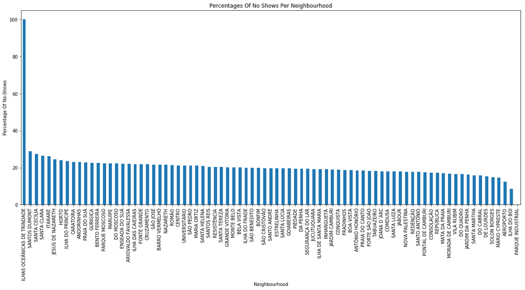

```python
hoods_No_show = df[df['No-show']=='Yes'].groupby(['Neighbourhood']).count()['No-show']
hoods = df.groupby(['Neighbourhood']).count()['No-show']
hoods_show = df[df['No-show']=='No'].groupby(['Neighbourhood']).count()['No-show']

percentages_No_show = hoods_No_show/hoods*100
percentages_No_show.sort_values()

# Plotting percentages of no_shows per neighbourhood
percentages_No_show.sort_values(ascending=False).plot(kind='bar', title='Percentages of No shows per Neighbourhood'.title(), figsize=(20,8));
plt.ylabel('Percentage of no-shows'.title().replace("_"," "))
plt.xlabel('neighbourhood'.title());
```

##### observation: Percentage of No-shows of ' ILHAS OCEÂNICAS DE TRINDADE ' Neighbourhood is the highest

```python
df['AppointmentDay'].value_counts()
```

```
2016-06-06 00:00:00+00:00    4692
2016-05-16 00:00:00+00:00    4613
2016-05-09 00:00:00+00:00    4520
2016-05-30 00:00:00+00:00    4514
2016-06-08 00:00:00+00:00    4479
2016-05-11 00:00:00+00:00    4474
2016-06-01 00:00:00+00:00    4464
2016-06-07 00:00:00+00:00    4416
2016-05-12 00:00:00+00:00    4394
2016-05-02 00:00:00+00:00    4376
2016-05-18 00:00:00+00:00    4373
2016-05-17 00:00:00+00:00    4372
2016-06-02 00:00:00+00:00    4310
2016-05-10 00:00:00+00:00    4308
2016-05-31 00:00:00+00:00    4279
2016-05-05 00:00:00+00:00    4273
2016-05-19 00:00:00+00:00    4270
2016-05-03 00:00:00+00:00    4256
2016-05-04 00:00:00+00:00    4168
2016-06-03 00:00:00+00:00    4090
2016-05-24 00:00:00+00:00    4009
2016-05-13 00:00:00+00:00    3987
2016-05-25 00:00:00+00:00    3909
2016-05-06 00:00:00+00:00    3879
2016-05-20 00:00:00+00:00    3828
2016-04-29 00:00:00+00:00    3235
2016-05-14 00:00:00+00:00      39
Name: AppointmentDay, dtype: int64
```

```python
df['ScheduledDay'].value_counts()
```

```
2016-05-06 07:09:54+00:00    24
2016-05-06 07:09:53+00:00    23
2016-04-25 17:18:27+00:00    22
2016-04-25 17:17:46+00:00    22
2016-04-25 17:17:23+00:00    19
                             ..
2016-04-25 08:45:17+00:00     1
2016-05-02 08:09:10+00:00     1
2016-05-12 11:16:29+00:00     1
2016-05-24 11:35:37+00:00     1
2016-05-19 16:59:13+00:00     1
Name: ScheduledDay, Length: 103549, dtype: int64
```

```python
# Continue to explore the data to address your additional research
#   questions. Add more headers as needed if you have more questions to
#   investigate.
```

```python
df.groupby('Gender')['Age'].mean()
```

```
Gender
F    38.893987
M    33.736863
Name: Age, dtype: float64
```

### what the effect of Gender and Hipertension in show appointment?

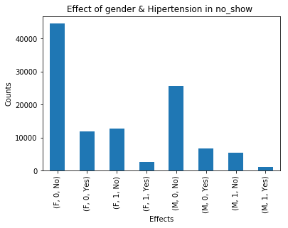

```python
df.groupby(['Gender','Hipertension'])['No-show'].value_counts().plot(kind='bar')
plt.title('Effect of gender & Hipertension in no_show ')
plt.ylabel('counts'.title())
plt.xlabel('effects'.title());
```

## observation:

#### First:The number of females don't have Hypertension and show up grater than number of males don't have Hypertension and show up

#### Second : The number of females don't have Hypertension and don't show up grater than number of males don't have Hypertension and don't show up

#### Third: The number of females have Hypertension and show up grater than number of males have Hypertension and show up

#### Fourth : The number of females have Hypertension and don't show up grater than number of males have Hypertension and don't show up

### what the effect of Gender and Diabetes in show appointment?

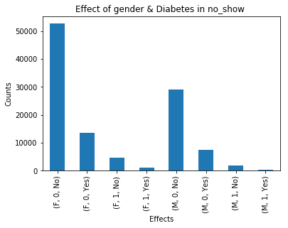

```python
df.groupby(['Gender','Diabetes'])['No-show'].value_counts().plot(kind='bar')
plt.title('Effect of gender & Diabetes in no_show ')
plt.ylabel('counts'.title())
plt.xlabel('effects'.title());
```

## observation:

#### First:The number of females don't have Diabetes and show up grater than number of males don't have Diabetes and show up

#### Second : The number of females don't have Diabetes and don't show up grater than number of males don't have Diabetes and don't show up

#### Third: The number of females have Diabetes and show up grater than number of males have Diabetes and show up

#### Fourth : The number of females have Diabetes and don't show up grater than number of males have Diabetes and don't show up

### what the effect of Gender and Handcap in show appointment?

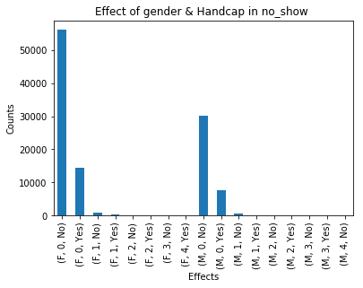

```python
df.groupby(['Gender','Handcap'])['No-show'].value_counts().plot(kind='bar')
plt.title('Effect of gender & Handcap in no_show ')
plt.ylabel('counts'.title())
plt.xlabel('effects'.title());
```

## observation:

#### First:The number of females don't have Handicap and show up grater than number of males don't have Handicap and show up

#### Second : The number of females don't have Handicap and don't show up grater than number of males don't have Handicap and don't show up

#### Third: The number of females have one Handicap and show up grater than number of males have one Handicap and show up

### what the effect of Gender and Alcoholism in show appointment?

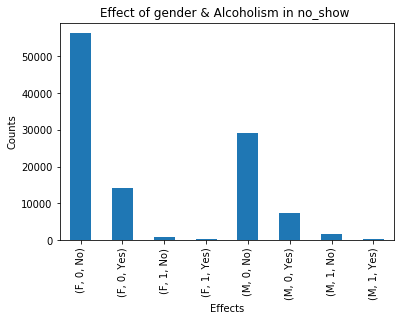

```python
df.groupby(['Gender','Alcoholism'])['No-show'].value_counts().plot(kind='bar')
plt.title('Effect of gender & Alcoholism in no_show ')
plt.ylabel('counts'.title())
plt.xlabel('effects'.title());
```

## Limitations:

#### This data analysis, from my point of view, there may be other relationships that can be expressed to better analyze this data. For example, the relationship of these two columns 'AppointmentDay' ,'ScheduledDay' could be expressed with the column 'No-show', and this was not addressed in this analysis.

#### Also, in visalization, the relationship between gender and age can be expressed, and their combined effect on no show.

```python
from subprocess import call
call(['python', '-m', 'nbconvert', 'Investigate_a_Dataset.ipynb'])
```

```
0
```